# Clase 2 - Guía de trabajo Variables Aleatorias Continuas

Diplomado en Análisis de datos con R para la Acuicultura.

Dr. José A. Gallardo Matus y Dra. María Angélica Rueda

Pontificia Universidad Católica de Valparaíso  
jose.gallardo@pucv.cl

11 April 2022

### **Introducción**

**¿Cuál es la diferencia entre variable y dato?**

Las **variables** son las características que se pueden medir en un individuo o en un ambiente y los **datos** son los valores que puede tomar esa variable.

**¿Qué es una variable aleatoria?**

Es una variable cuyo valor se determina por el azar. Las variables aleatorias se representan por letras mayúsculas (**X**) y sus valores numéricos por letras minúsculas ($x_i$).

### **Clasificación de variables cuantitativas**

[output not shown]

### **Clasificación de variables cualitativas o categóricas**

| **Tipo de variable** | **Descripción** |
| --- | --- |
| **Variables nominales:** | Sus valores representan categorías que no obedecen a una clasificación intrínseca. |
| **Variables ordinales:** | Sus valores representan categorías con alguna clasificación intrínseca. |

### **Distribución de una variable**

*Distribución empírica (observación)*: Los datos de una muestra, obtenidos de forma aleatoria de una población, pueden ser usados para observar su comportamiento o distribución.

*Distribución de probabilidad (predicción)*: Las variables aleatorias tienen diferentes distribuciones de probabilidad subyacentes, lo que nos permite predecir su comportamiento y realizar inferencia estadística.

*Distribución normal*: Las variables cuantitativas continuas podrían seguir una distribución normal.

### **¿Cómo puedo observar y predecir el comportamiento de una variable?**

En la siguiente tabla se muestran varias **funciones clave** para poder observar o predecir el comportamiento de una variable aleatoria.

| **Librería** | **Función** | **Descripción** |
| --- | --- | --- |
| base | **table()** | Tabla de distribución de frecuencia para factores. |
| base | **plot()** | Gráfico x-y de puntos “p”, líneas “l” o ambas “b”. |
| graphics | **hist()** | Histograma para variables cuantitativas |
| graphics | **boxplot()** | Gráfico de cajas y bigotes |
| graphics | **barplot()** | Gráfico de barras |
| stats | **density()** | Función de densidad empírica |
| stats | **ecdf()** | Función de distribución acumulada empírica |

### **¿Qué puedo medir de una variable aleatoria continua?**

| **Librería** | **Función** | **Descripción** |
| --- | --- | --- |
| base | **mean()** | Media aritmética |
| base | **range()** | Rango |
| stats | **median()** | Mediana |
| stats | **var()** | Varianza |
| stats | **sd()** | Desviación estándar |
| stats | **quantile()** | Concentración de datos en cuantiles |
| stats | **cor()** | Correlación con otra variable |

### **¿Cómo puedo simular números aleatorios con distribución normal?**

| **Librería** | **Función** | **Descripción** |
| --- | --- | --- |
| stats | **rnorm(n, mean, sd)** | Genera (n) números aleatorios para la distribución normal con promedio (mean) y desviación estandar (sd) |

### **Objetivos de aprendizaje**

Los objetivos de aprendizaje de esta guía son:

**1**. Observar y predecir una variable aleatoria continua con distribución normal.

## **Ejercicios**

### **Ejercicio 1.** **Elaborar un Script de R (Archivo .R)**

Elabore un archivo o file con extensión **.R** usando la barra de herramientas de **Rstudio**. Selecciona **File > New file > R script**. Utilice el siguiente ejemplo para completar la información de **metadatos** del script.

```
# ----------------------------------------------------------
# Clase 02 - Guia Variables Aleatorias continuas.
# Su nombre:
# 09 abril 2022.
# Diplomado en Análisis de datos con R para la Acuicultura..
# ----------------------------------------------------------
```

Luego, guarde inmediatamente su script como **script_2_nombre_apellido.R**.

### **Ejercicio 2.** **Configuración de librerías**

Debajo del **metadatos** habilite el paquete **readxl** usando la función **library()**. Note que los paquetes **base**, **stats**, **utils** y **graphics** ya están habilitados.

```r
knitr::opts_chunk$set(echo = FALSE)
library(readxl)
```

### **Ejercicio 3.** **Peso y talla de Salmones del Atlántico.**

El set de datos **datos.xlsx** contiene información de peso (**Peso**) y talla (**Talla**) de 100 salmones del Atlántico un estanque, los cuales se clasificaron según su sexo en **Hembra** o **Macho**.

Cree un objeto llamado **salmones** e importe el set de datos **datos.xlsx** usando la función **read_excel** de la librería **readxl**.

Explore el set de datos algunas funciones de la librería **{utils}** **head()**, **tail()**, **str()** y de la librería **{base}** **summary**.

```
## # A tibble: 6 × 4
##   Animal Talla  Peso Sexo
##    <dbl> <dbl> <dbl> <chr>
## 1      1  72.3 2821. Hembra
## 2      2  79.8 5639. Macho
## 3      3  62.4 5263. Hembra
## 4      4  75.1 7397. Macho
## 5      5  85.8 6742. Macho
## 6      6  84.7 6755. Hembra
```

```
## # A tibble: 6 × 4
##   Animal Talla  Peso Sexo
##    <dbl> <dbl> <dbl> <chr>
## 1     95  78.7 6847. Macho
## 2     96  81.9 7545. Macho
## 3     97  71.5 6075. Macho
## 4     98  76.7 7395. Macho
## 5     99  74.9 5402. Macho
## 6    100  67.4 7249. Hembra
```

```
## tibble [100 × 4] (S3: tbl_df/tbl/data.frame)
##  $ Animal: num [1:100] 1 2 3 4 5 6 7 8 9 10 ...
##  $ Talla : num [1:100] 72.3 79.8 62.4 75.1 85.8 ...
##  $ Peso  : num [1:100] 2821 5639 5263 7397 6742 ...
##  $ Sexo  : chr [1:100] "Hembra" "Macho" "Hembra" "Macho" ...
```

```
##      Animal           Talla            Peso          Sexo
##  Min.   :  1.00   Min.   :61.32   Min.   :2627   Length:100
##  1st Qu.: 25.75   1st Qu.:73.18   1st Qu.:5065   Class :character
##  Median : 50.50   Median :76.82   Median :5825   Mode  :character
##  Mean   : 50.50   Mean   :77.03   Mean   :5864
##  3rd Qu.: 75.25   3rd Qu.:80.49   3rd Qu.:6656
##  Max.   :100.00   Max.   :91.10   Max.   :8636
```

### **Ejercicio 4.** **Corrección de variables**

Note que en el ejercicio anterior la variable **Sexo** fue codificada como caracter o texto (chr) en vez de factor. Use la función **as.factor(salmones$Sexo)** para indicar que Sexo es un factor de clasificación. Vuelva a ejecutar los comandos **summary()** y **str()** para comprobar que las variables están adecuadamente codificadas.

```
##      Animal           Talla            Peso          Sexo
##  Min.   :  1.00   Min.   :61.32   Min.   :2627   Hembra:51
##  1st Qu.: 25.75   1st Qu.:73.18   1st Qu.:5065   Macho :49
##  Median : 50.50   Median :76.82   Median :5825
##  Mean   : 50.50   Mean   :77.03   Mean   :5864
##  3rd Qu.: 75.25   3rd Qu.:80.49   3rd Qu.:6656
##  Max.   :100.00   Max.   :91.10   Max.   :8636
```

```
## tibble [100 × 4] (S3: tbl_df/tbl/data.frame)
##  $ Animal: num [1:100] 1 2 3 4 5 6 7 8 9 10 ...
##  $ Talla : num [1:100] 72.3 79.8 62.4 75.1 85.8 ...
##  $ Peso  : num [1:100] 2821 5639 5263 7397 6742 ...
##  $ Sexo  : Factor w/ 2 levels "Hembra","Macho": 1 2 1 2 2 1 1 2 1 1 ...
```

### **Ejercicio 5.** **Observar el comportamiento de una variable**

A partir del set de datos **salmones** elabore un histograma y un boxplot de la variable cuantitativa continua **Peso**. Use las funciones **hist()**, **boxplot()**. Incluya títulos y leyenda de los ejes con los argumentos *col=““*,* main =”“* y *xlab=““*.

Investigue y use este comando **par(mfrow=c(1,2))** para unir las gráficas en un solo panel con dos columnas.

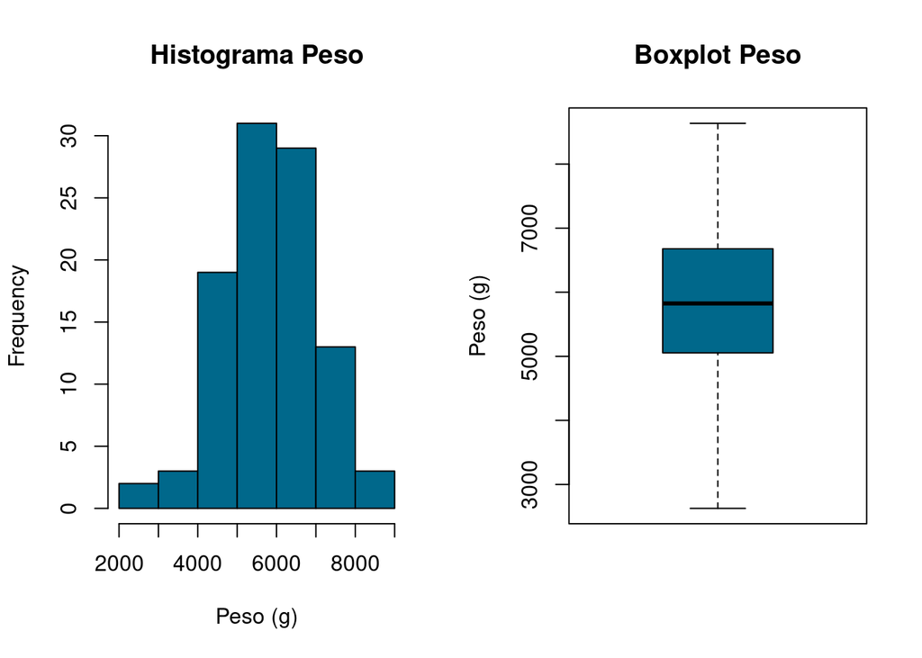

### **Ejercicio 6.** **Métricas del set de datos salmones**

Calcule las siguientes métricas del set de datos: promedio, desviación estándar, rango y cuantiles usando las funciones: **mean()**, **sd()**, **range()** y **quantile()**.

```
## [1] 5864.144
```

```
## [1] 1171.266
```

```
## [1] 2626.997 8636.039
```

```
##       0%      25%      50%      75%     100%
## 2626.997 5064.840 5824.989 6655.946 8636.039
```

### **Ejercicio 7.** **Función de densidad**

Usando la función **plot()** elabore:

**a).** Gráfico con la densidad empírica. Debe incluir la función **density()** dentro de la función **plot()**.

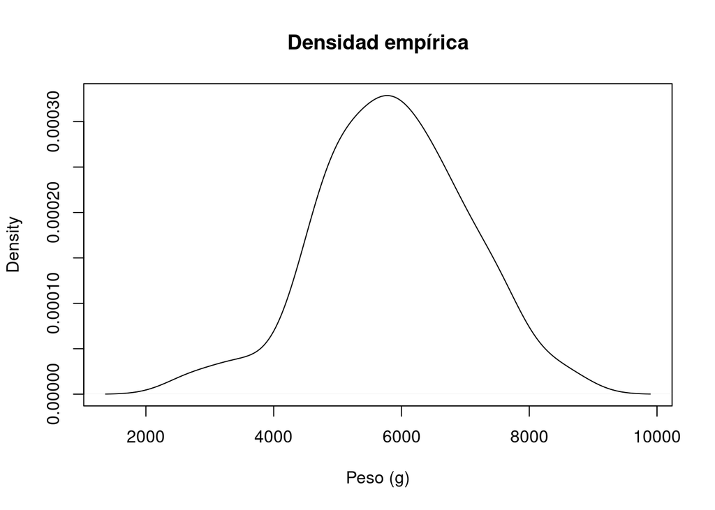

**b).** Gráfico con la distribución acumulada empírica. Debe incluir la función **ecdf()** dentro de la función **plot()**.

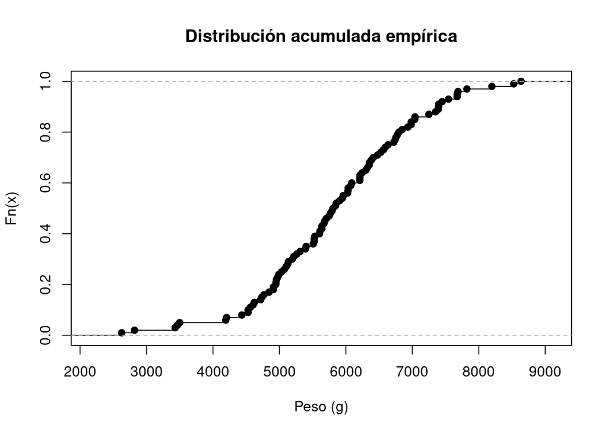

```r
# Distribución acumulada empírica.
plot(ecdf(salmones$Peso), main="Distribución acumulada empírica", xlab="Peso (g)")
```

### **Ejercicio 8.** **Crear una función y predecir datos observados**

**a).** Primero cree un un objeto llamado **Fn** con la función de distribución acumulada empírica para los datos del peso de sus animales.

```r
Fn <- ecdf(salmones$Peso)
Fn
```

```
## Empirical CDF
## Call: ecdf(salmones$Peso)
##  x[1:100] =   2627, 2820.7,   3431,  ..., 8526.1,   8636
```

**b).** Calcule la proporción de animales menores de 5000 g. Use la función paste() para redactar su resultado de forma automática.

```r
# Fn(x) returns the percentiles for x
paste("La proporción de animales menores a 5000 g es = ", Fn(5000)*100, "%")
```

```
## [1] "La proporción de animales menores a 5000 g es =  24 %"
```

**c).** Calcule la proporción de animales mayor a 5000 g. Use la función paste() para redactar su resultado de forma automática.

```r
# 1- Fn(x) returns 1 - the percentiles for x
paste("La proporción de animales mayores a 5000 g es = ", ((1 - Fn(5000))*100), "%")
```

```
## [1] "La proporción de animales mayores a 5000 g es =  76 %"
```